# Artificial Neural Network Application for Reservoir Characterization

[Chukwuemeka Okoli](https://www.linkedin.com/in/chukwuemeka-okoli-38686923/)

April, 09, 2019

## Introduction

As a Data Scientist in the Oil and Gas Industry, we are often faced with numerous challenges. For instance, with available Gas production data for an unconventional reservoir, can we establish a relationship between several independent variable in the production process and the dependent variable “Gas production per months” using Artificial Neural Network. In this [R Markdown](https://rmarkdown.rstudio.com) project, an illustration of how we can apply Artificial Neural Network to Gas production is discussed. The dataset for this project is the “Q4_data.csv” file.

## The Goal

Find a relationship between the dependent variable “Gas production per months” and several independent variables. Essentially, we want to determine the Gas Production per month for the given well data based on different factors.

## Preliminaries

First, the required packages are installed using the `install.packages()` function.

```r
# install knitr
install.packages("knitr")

# install the rmarkdown package
install.packages("rmarkdown")

# install ggplot for plotting
install.packages("ggplot2")

# install dplyr for data manipulation
install.packages("dplyr")

# install neuralnet for artificial neural network
install.packages("neuralnet")
install.packages("NeuralNetTools")
```

The installed package is then loaded using the `library()` function.

```r
# load libraries
library(knitr)
library(rmarkdown)
library(ggplot2)
library(dplyr)
library(neuralnet)
library(NeuralNetTools)
library(xfun)
```

### Data Import

We can call in the dataset into R using the code below. The data is stored in a `.csv` file.

```r
set.seed(440)
data <- read.csv("Q4_data.csv", header=TRUE)
```

### Summaries

```r
summary(data)
```

```
    Perf_Int         Frac_vol          Proppant           N.frac        Tubing.depth    Casing.depth
 Min.   :  12.0   Min.   :   7478   Min.   :  43500   Min.   : 1.000   Min.   : 4952   Min.   : 7325
 1st Qu.: 381.8   1st Qu.:  29524   1st Qu.: 164625   1st Qu.: 1.000   1st Qu.: 7652   1st Qu.: 8176
 Median : 474.0   Median :  36200   Median : 296946   Median : 2.000   Median : 8002   Median : 8745
 Mean   : 708.1   Mean   :  56848   Mean   : 662449   Mean   : 2.309   Mean   : 8020   Mean   : 9044
 3rd Qu.: 802.5   3rd Qu.:  56876   3rd Qu.:1135250   3rd Qu.: 3.000   3rd Qu.: 8407   3rd Qu.: 9694
 Max.   :4555.0   Max.   :3637776   Max.   :4437897   Max.   :11.000   Max.   :12100   Max.   :13144
      FTP           Choke.Size         SITHP          SG_gas         Well_Type        Latitude
 Min.   :   0.0   Min.   :  6.00   Min.   : 300   Min.   :0.5810   Min.   :1.000   Min.   :     33
 1st Qu.: 450.0   1st Qu.: 14.00   1st Qu.:1615   1st Qu.:0.7000   1st Qu.:2.000   1st Qu.:     33
 Median : 814.1   Median : 20.00   Median :2278   Median :0.7000   Median :3.000   Median :     33
 Mean   : 905.6   Mean   : 28.18   Mean   :2250   Mean   :0.6922   Mean   :2.504   Mean   :   7737
 3rd Qu.:1265.0   3rd Qu.: 32.00   3rd Qu.:2913   3rd Qu.:0.7000   3rd Qu.:3.000   3rd Qu.:     33
 Max.   :2964.0   Max.   :128.00   Max.   :3715   Max.   :1.0320   Max.   :3.000   Max.   :3436128
     Long.           Gas_prod            Acid
 Min.   :-97.40   Min.   :     95   Min.   :1.000
 1st Qu.:-97.35   1st Qu.:   3840   1st Qu.:1.000
 Median :-97.31   Median :   6392   Median :1.000
 Mean   :-97.00   Mean   :  13281   Mean   :1.193
 3rd Qu.:-97.26   3rd Qu.:  13155   3rd Qu.:1.000
 Max.   : 33.04   Max.   :1189790   Max.   :2.000
```

The `set.seed()` function is useful when running simulations to ensure all results, figures, etc. are reproducible. We can then check that no data point is missing. If we have a missing data point, we need to fix the dataset.

```r
# Check that no data is missing
apply(data,2,function(x) sum(is.na(x)))
```

```
    Perf_Int     Frac_vol     Proppant       N.frac Tubing.depth Casing.depth          FTP   Choke.Size
           0            0            0            0            0            0            0            0
       SITHP       SG_gas    Well_Type     Latitude        Long.     Gas_prod         Acid
           0            0            0            0            0            0            0
```

We can see that there is no missing data. In the case where missing data exist, data cleaning will have to take place.

## Data Analysis

To analyze the data, we first proceed by randomly splitting the data into a *train* and a *test* dataset. A linear regression model is fit to the train dataset, and tested on the test dataset.

```r
# Train-test random splitting for linear model
index <- sample(1:nrow(data), round(0.75*nrow(data)))
train <- data[index,]
test <- data[-index,]

# Fitting linear model to the train dataset
lm.fit <- lm(Gas_prod~., data=train)
summary(lm.fit)
```

```
Call:
lm(formula = Gas_prod ~ ., data = train)

Residuals:
    Min      1Q  Median      3Q     Max
 -47760  -10702   -1399    5105 1129607

Coefficients:
               Estimate Std. Error t value Pr(>|t|)
(Intercept)   3.573e+06  6.758e+06   0.529  0.59736
Perf_Int      7.679e+00  9.322e+00   0.824  0.41069
Frac_vol     -1.647e-03  1.826e-02  -0.090  0.92819
Proppant     -4.752e-03  8.889e-03  -0.535  0.59329
N.frac        3.632e+03  3.265e+03   1.112  0.26682
Tubing.depth  1.817e+00  8.838e+00   0.206  0.83724
Casing.depth -4.891e+00  6.737e+00  -0.726  0.46836
FTP           1.546e+01  7.879e+00   1.962  0.05066 .
Choke.Size   -1.260e+02  1.654e+02  -0.762  0.44679
SITHP        -9.587e+00  5.605e+00  -1.710  0.08819 .
SG_gas        1.873e+04  8.791e+04   0.213  0.83140
Well_Type    -1.782e+04  5.966e+03  -2.987  0.00303 **
Latitude     -1.354e+00  2.630e+00  -0.515  0.60699
Long.         3.588e+04  6.928e+04   0.518  0.60494
Acid         -5.866e+03  9.900e+03  -0.592  0.55394
---
Signif. codes:  0 ‘***’ 0.001 ‘**’ 0.01 ‘*’ 0.05 ‘.’ 0.1 ‘ ’ 1

Residual standard error: 64820 on 319 degrees of freedom
Multiple R-squared:  0.0564,    Adjusted R-squared:  0.01499
F-statistic: 1.362 on 14 and 319 DF,  p-value: 0.1702
```

```r
# Predicted data from linear model fit
pr.lm <- predict(lm.fit, test)

# Test MSE
MSE.lm <- sum((pr.lm - test$Gas_prod)^2)/nrow(test)
```

Before fitting a neural network, some preparation needs to be done. Neural networks are not that easy to train and tune. As a first step, we need to address data preprocessing. It is good practice to normalize your data before training a neural network. This step is important because, depending on your dataset, avoiding normalization may lead to useless results or to a very difficult training process (most of the time, the algorithm will not converge before the number of maximum iterations allowed). You can choose different methods to scale the data (z-normalization, min-max scale, etc.). The data were scaled using the min-max method and scaled in the interval [0,1]. We therefore scale and split the data before moving on.

```r
# Neural network fitting

# Scaling data for the Neural Network
maxs <- apply(data, 2, max)
mins <- apply(data, 2, min)
scaled <- as.data.frame(scale(data, center = mins, scale = maxs - mins))

# Train-test split
train_ <- scaled[index,]
test_ <- scaled[-index,]
```

Since there is no fixed rule as to how many layers and neurons to use, we are going to use two (2) hidden layers with 5 and 3 neurons. To fit the network, we use the following code:

```r
# Training the neural network
n <- names(train_)
f <- as.formula(paste("Gas_prod ~", paste(n[!n %in% "Gas_prod"], collapse = " + ")))
neural_net <- neuralnet(f, data = train_, hidden = c(5,3), linear.output = T)
```

Note that the hidden argument accepts a vector with the number of neurons for each hidden layer, while the argument linear.output is used to specify whether we want to do regression **linear.output = TRUE** or **classification linear.output = FALSE**

The neuralnet package provides a nice tool to plot the model. Use the following code to plot the neural network in R:

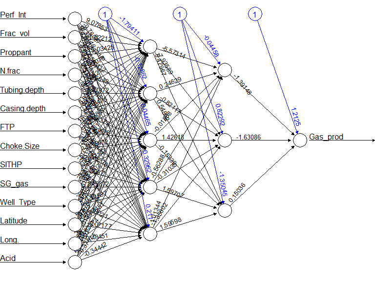

```r
# Visual plot of the model
plot(neural_net)
```

Now we can try to predict the values for the test set and calculate the mean squared error (MSE). Remember that the net will output a normalized prediction, so we need to scale it back in order to make a meaningful comparison (or just a simple prediction). The mean squared error is one metric used to measure prediction accuracy. The MSE is calculated as:

$$MSE = \frac{1}{n} \sum_{i=1}^{n}(Y_i - \hat{Y_i}^2)$$

```r
# Prediction
pr.nn <- compute(neural_net, test_[,1:14])

# Results from Neural Networks are normalized (scaled)
# Descaling for comparison
pr.nn_ <- pr.nn$net.result*(max(data$Gas_prod)-min(data$Gas_prod))+min(data$Gas_prod)
test.r <- (test_$Gas_prod)*(max(data$Gas_prod)-min(data$Gas_prod))+min(data$Gas_prod)

# Calculating MSE
MSE.nn <- sum((test.r - pr.nn_)^2)/nrow(test_)
```

We then compare the two mean squares error obtained from the linear regression and the neural network fitting process using the code:

```r
# Compare the two Mean Squared Errors (MSEs)
print(paste(MSE.lm, MSE.nn))
```

```
[1] "229551018.949411 204157020.027424"
```

```r
# Plot predictions
par(mfrow=c(1,2))

plot(test$Gas_prod, pr.nn_, col='red', main='Real vs predicted NN', pch=18, cex=0.7)
abline(0,1,lwd=2)
```

```r
legend('bottomright', legend='NN', pch=18, col='red', bty='n')

plot(test$Gas_prod, pr.lm, col='blue', main='Real vs predicted lm', pch=18, cex=0.7)
```

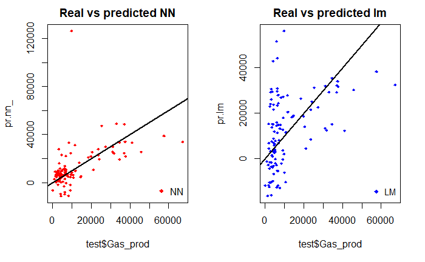

```r
abline(0,1,lwd=2)
legend('bottomright', legend='LM', pch=18, col='blue', bty='n', cex=.95)
```

By visually inspecting the plot, we can see that the predictions made by the neural network are more concentrated around the line than those made by the linear model. We can obtain a more useful visual comparison using the code below

```r
# Compare predictions on the same plot
plot(test$Gas_prod, pr.nn_, col='red', main='Real vs predicted NN', pch=18, cex=0.7)
points(test$Gas_prod, pr.lm, col='blue', pch=18, cex=0.7)
```

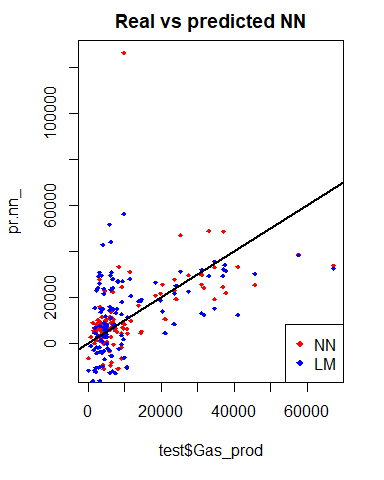

```r
abline(0,1,lwd=2)
legend('bottomright', legend=c('NN','LM'), pch=18, col=c('red','blue'))
```

The comparison of prediction on the same plot is shown above.In analyzing the model above, we allowed the network select the training, validation and testing dataset itself by randomly splitting the data into a train and a test set, then a linear regression model is fit and then tested on the test set.

If we choose to select the training, validation and testing datasets ourselves, we normalize our data and split into training and test data as before.

```r
# Neural net fitting
set.seed(440)
mydata <- read.csv("Q4_data.csv", header=TRUE)

#Normalizing the dataset
normalize <- function(x) {
  return ((x - min(x)) / (max(x) - min(x)))
}

maxmindf <- as.data.frame(lapply(mydata, normalize))
```

```r
# Display head of data
head(mydata)
```

|  | Perf_Int | Frac_vol | Proppant | N.frac | Tubing.depth | Casing.depth | FTP | Choke.Size | SITHP | SG_gas | Well_Type | Latitude | Long. | Gas_prod | Acid |
| --- | --- | --- | --- | --- | --- | --- | --- | --- | --- | --- | --- | --- | --- | --- | --- |
| 1 | 280 | 19454.76 | 408550 | 2 | 7754 | 8067 | 185.0 | 42 | 2815 | 0.6790 | 1 | 33.05307 | -97.19147 | 7135.18 | 1 |
| 2 | 757 | 58477.00 | 407000 | 1 | 8843 | 9081 | 490.0 | 40 | 1915 | 0.5890 | 1 | 33.16222 | -97.38986 | 3720.74 | 1 |
| 3 | 532 | 27262.00 | 129400 | 1 | 7963 | 8515 | 565.0 | 22 | 3015 | 0.7000 | 1 | 33.01159 | -97.27166 | 6200.33 | 1 |
| 4 | 345 | 31622.74 | 321300 | 1 | 7832 | 8039 | 615.0 | 20 | 2350 | 0.8000 | 1 | 33.14988 | -97.14882 | 4096.05 | 1 |
| 5 | 856 | 18596.76 | 390532 | 2 | 8602 | 9065 | 715.0 | 24 | 3250 | 0.6621 | 1 | 33.04807 | -97.27381 | 4687.49 | 1 |
| 6 | 470 | 34785.71 | 190000 | 1 | 7470 | 7810 | 1235.2 | 10 | 2250 | 0.7000 | 1 | 33.23879 | -97.30187 | 3551.04 | 1 |

```r
# Display tail of data
tail(mydata)
```

|  | Perf_Int | Frac_vol | Proppant | N.frac | Tubing.depth | Casing.depth | FTP | Choke.Size | SITHP | SG_gas | Well_Type | Latitude | Long. | Gas_prod | Acid |
| --- | --- | --- | --- | --- | --- | --- | --- | --- | --- | --- | --- | --- | --- | --- | --- |
| 441 | 718 | 52929.00 | 701000 | 1 | 8851 | 8869 | 700 | 32 | 2200 | 0.60 | 3 | 33.14809 | -97.16659 | 5882.4167 | 2 |
| 442 | 575 | 28945.00 | 465800 | 2 | 8115 | 8532 | 680 | 24 | 2450 | 0.64 | 3 | 33.19194 | -97.25327 | 5013.8594 | 1 |
| 443 | 786 | 52379.00 | 352572 | 3 | 8426 | 9151 | 1365 | 20 | 2910 | 0.70 | 3 | 33.25706 | -97.21546 | 1226.4308 | 2 |
| 444 | 740 | 23752.00 | 203500 | 2 | 8149 | 9200 | 439 | 18 | 2714 | 0.72 | 3 | 33.24925 | -97.20252 | 887.2319 | 1 |
| 445 | 702 | 24676.00 | 294765 | 2 | 8484 | 9245 | 1365 | 14 | 3070 | 0.70 | 3 | 33.25470 | -97.20097 | 4863.2192 | 1 |
| 446 | 372 | 28928.57 | 115250 | 1 | 7370 | 7644 | 1500 | 9 | 2865 | 0.70 | 3 | 33.01804 | -97.31887 | 2798.9756 | 1 |

Since we know the size of the data, we then proceed to test and train the network. We have chosen to split the training and testing dataset into a 70/30 ratio .i.e. 70% (for training) and 30% (for testing) instead of allowing the network do the splitting for us.

```r
# Training and Test Data
trainset <- maxmindf[1:312, ]
testset <- maxmindf[313:446, ]
```

We fit the network and arbitrarily decide on the number of hidden neurons. Deciding on the number of hidden layers in a neural network is not an exact science. In fact, there are instances where accuracy will likely be higher without any hidden layers. Therefore, trial and error plays a significant role in this process. One possibility is to compare how the accuracy of the predictions change as we modify the number of hidden layers. If we use 3 and 2 hidden layers, we obtain:

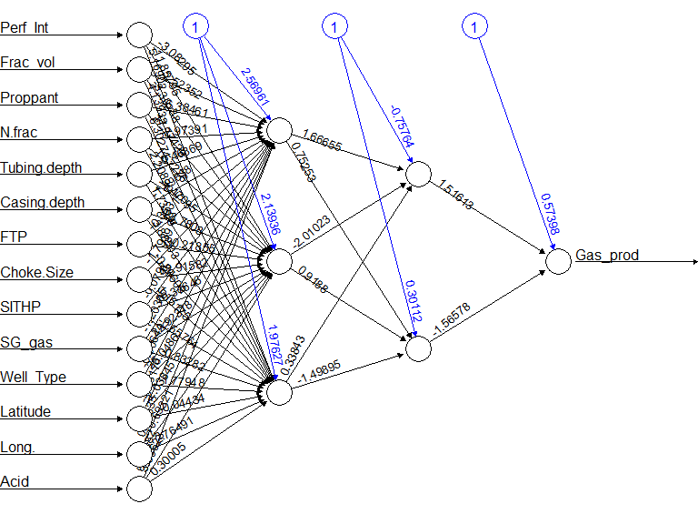

```r
# Neural Network Training
library(neuralnet)
nn <- neuralnet(Gas_prod ~ Perf_Int + Frac_vol + Proppant + N.frac +
                Tubing.depth + Casing.depth + FTP + Choke.Size + SITHP +
                SG_gas + Well_Type + Latitude + Long. + Acid, data=trainset,
                hidden=c(3,2), linear.output=TRUE, threshold=0.01)
nn$result.matrix
# Visual plot of the model
plot(nn)
```

[output not shown]

The output from the neural network training is shown above. Our neural network has been created using the training data. We then compare this to the test data to gauge the accuracy of the neural network forecast.

```r
#Test the resulting output
temp_test <- subset(testset, select = c("Gas_prod", "Perf_Int", "Frac_vol",
                                        "Proppant", "N.frac", "Tubing.depth",
                                        "Casing.depth",  "FTP", "Choke.Size",
                                        "SITHP", "SG_gas", "Well_Type", "Latitude",
                                        "Long.", "Acid"))
head(temp_test)
```

|  | Gas_prod | Perf_Int | Frac_vol | Proppant | N.frac | Tubing.depth | Casing.depth | FTP | Choke.Size | SITHP | SG_gas | Well_Type | Latitude | Long. | Acid |
| --- | --- | --- | --- | --- | --- | --- | --- | --- | --- | --- | --- | --- | --- | --- | --- |
| 313 | 0.0115296075 | 0.14902047 | 0.006530593 | 0.08508562 | 0.0 | 0.4555120 | 0.2342327 | 0.84480432 | 0.03278689 | 0.9411420 | 0.04212860 | 1 | 5.820619e-08 | 0.0009938915 | 0 |
| 314 | 0.0045662511 | 0.05414924 | 0.005322704 | 0.04983619 | 0.2 | 0.4542529 | 0.2495274 | 0.29159919 | 0.08196721 | 0.8533821 | 0.23725055 | 1 | 6.377984e-08 | 0.0007750097 | 1 |
| 315 | 0.0041483181 | 0.14880035 | 0.005769774 | 0.05718191 | 0.0 | 0.3940963 | 0.2488400 | 0.17948718 | 0.11475410 | 0.8752562 | 0.04212860 | 1 | 6.267615e-08 | 0.0011130577 | 0 |
| 316 | 0.0029264959 | 0.08056350 | 0.004923563 | 0.01567906 | 0.0 | 0.3567431 | 0.1031105 | 0.43657220 | 0.06557377 | 0.8096633 | 0.26385809 | 1 | 2.029004e-08 | 0.0009770522 | 0 |
| 317 | 0.0009303225 | 0.11182038 | 0.007402423 | 0.07036233 | 0.3 | 0.4847510 | 0.3101908 | 0.08434548 | 0.34426230 | 0.1317716 | 0.01419069 | 1 | 5.168088e-08 | 0.0017725913 | 0 |
| 318 | 0.0042217903 | 0.15100154 | 0.003430199 | 0.03379303 | 0.1 | 0.4956631 | 0.2758206 | 0.36099865 | 0.08196721 | 0.8067350 | 0.26385809 | 1 | 7.107848e-08 | 0.0010241715 | 0 |

```r
nn.results <- compute(nn, temp_test)
```

The predicted results are compared to the actual results. The code to do this and a snippet of the result is shown below:

```r
#Comparison of Predicted to Actual
results <- data.frame(actual = testset$Gas_prod, prediction = nn.results$net.result)
results
```

|  | actual | prediction |
| --- | --- | --- |
| 313 | 0.0115296075 | 0.0019106450 |
| 314 | 0.0045662511 | 0.0024498630 |
| 315 | 0.0041483181 | 0.0053135253 |
| 316 | 0.0029264959 | 0.0061688705 |
| 317 | 0.0009303225 | 0.0071988651 |
| 318 | 0.0042217903 | 0.0023350951 |
| 319 | 0.0052641792 | 0.0032005803 |
| 320 | 0.0065977434 | 0.0061051029 |
| 321 | 0.0033872906 | 0.0021572123 |
| 322 | 0.0051492189 | -0.0008556349 |

[output cut: 124 more lines]

We then test the accuracy of the model

```r
#Testing The Accuracy Of The Model
Gas_prod <- trainset$Gas_prod
predicted = results$prediction * abs(diff(range(Gas_prod))) + min(Gas_prod)
actual = results$actual * abs(diff(range(Gas_prod))) + min(Gas_prod)
comparison = data.frame(predicted, actual)

deviation = ((actual-predicted)/actual)
comparison = data.frame(predicted, actual, deviation)
```

In the above code, we are converting the data back to its original format. Note that we are also converting our data back into standard values given that they were previously scaled using the max-min normalization technique.

We compute the accuracy of network with (3,2) hidden layer. An accuracy of 61.8% on a mean absolute deviation basis (i.e. the average deviation between estimated and actual Gas production per month) was obtained.

```r
accuracy = 1-abs(mean(deviation))
accuracy
```

```
[1] 0.6187621
```

You can see that we obtain a high accuracy of 61.8 % accuracy using a (3,2) hidden configuration. This is quite good, especially considering that our dependent variable is in the interval format. However, let’s see if we can get it higher!

**What happens if we now use a (5,2) hidden configuration in our neural network?** Here is the generated output:

```r
nn <- neuralnet(Gas_prod ~ Perf_Int + Frac_vol + Proppant + N.frac + Tubing.depth
                + Casing.depth + FTP + Choke.Size + SITHP + SG_gas + Well_Type
                + Latitude + Long. + Acid,data=trainset, hidden=c(5,2),
                linear.output=TRUE, threshold=0.01)
nn$result.matrix
```

```
                                  [,1]
error                     3.653272e-03
reached.threshold         8.863541e-03
steps                     1.902000e+03
Intercept.to.1layhid1     2.412039e+00
Perf_Int.to.1layhid1     -3.022457e+00
Frac_vol.to.1layhid1     -2.706479e+00
Proppant.to.1layhid1      2.138009e+00
N.frac.to.1layhid1        6.900633e+00
Tubing.depth.to.1layhid1  3.020498e+00
Casing.depth.to.1layhid1 -1.606061e-01
FTP.to.1layhid1          -3.427725e-01
Choke.Size.to.1layhid1    2.963539e+00
SITHP.to.1layhid1        -7.742261e-02
SG_gas.to.1layhid1       -3.814676e-01
Well_Type.to.1layhid1     6.916603e-01
Latitude.to.1layhid1     -8.057662e-01
Long..to.1layhid1        -1.101212e+00
Acid.to.1layhid1          1.165234e+01
Intercept.to.1layhid2    -2.018957e+00
Perf_Int.to.1layhid2      4.331287e+00
Frac_vol.to.1layhid2      5.084424e-01
Proppant.to.1layhid2     -7.344221e+00
N.frac.to.1layhid2       -3.569281e+00
Tubing.depth.to.1layhid2 -5.241477e-01
Casing.depth.to.1layhid2 -1.099082e+00
FTP.to.1layhid2          -1.129401e+01
Choke.Size.to.1layhid2    3.903377e+00
SITHP.to.1layhid2         4.751302e+00
SG_gas.to.1layhid2        2.653925e+00
Well_Type.to.1layhid2     7.466284e+01
Latitude.to.1layhid2     -1.541364e+00
Long..to.1layhid2         9.906799e+00
Acid.to.1layhid2          1.626440e+00
Intercept.to.1layhid3     3.169506e+00
Perf_Int.to.1layhid3     -8.899430e+00
Frac_vol.to.1layhid3     -1.330377e+00
Proppant.to.1layhid3      8.086839e+01
N.frac.to.1layhid3       -6.402368e+00
Tubing.depth.to.1layhid3 -4.970220e-01
```

[output cut: 39 more lines]

```
Intercept.to.2layhid1     4.378251e-02
1layhid1.to.2layhid1     -6.734787e+00
1layhid2.to.2layhid1     -9.150114e-01
1layhid3.to.2layhid1      1.619814e+01
1layhid4.to.2layhid1     -5.075946e+01
1layhid5.to.2layhid1     -5.584953e+00
Intercept.to.2layhid2    -9.768579e-01
1layhid1.to.2layhid2      3.356849e+00
1layhid2.to.2layhid2     -1.576312e-01
1layhid3.to.2layhid2      4.974827e-01
1layhid4.to.2layhid2     -5.260432e+01
1layhid5.to.2layhid2     -2.530036e-01
Intercept.to.Gas_prod     9.835952e-01
2layhid1.to.Gas_prod     -5.681484e-01
2layhid2.to.Gas_prod     -4.410568e-01
```

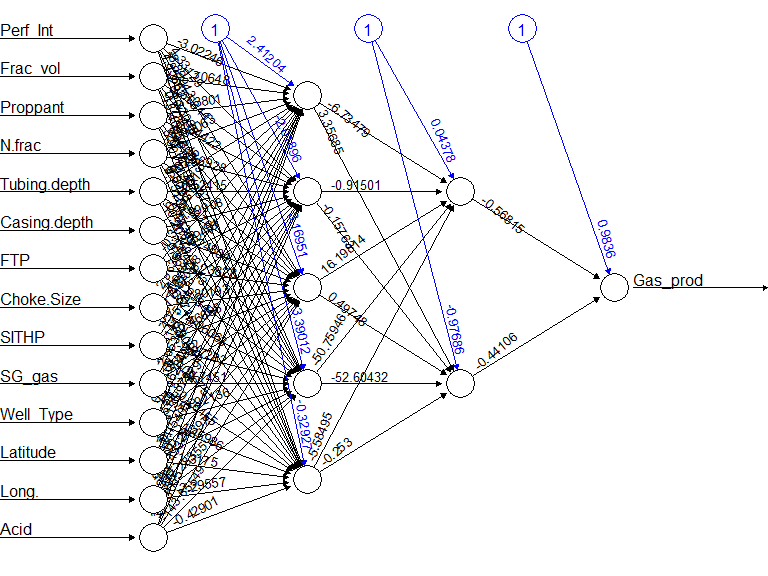

```r
plot(nn)
```

```r
#Test the resulting output
temp_test <- subset(testset, select = c("Gas_prod", "Perf_Int", "Frac_vol",
                                        "Proppant", "N.frac", "Tubing.depth",
                                        "Casing.depth",  "FTP", "Choke.Size",
                                        "SITHP", "SG_gas", "Well_Type", "Latitude",
                                        "Long.", "Acid"))
head(temp_test)
```

|  | Gas_prod | Perf_Int | Frac_vol | Proppant | N.frac | Tubing.depth | Casing.depth | FTP | Choke.Size | SITHP | SG_gas | Well_Type | Latitude | Long. | Acid |
| --- | --- | --- | --- | --- | --- | --- | --- | --- | --- | --- | --- | --- | --- | --- | --- |
| 313 | 0.0115296075 | 0.14902047 | 0.006530593 | 0.08508562 | 0.0 | 0.4555120 | 0.2342327 | 0.84480432 | 0.03278689 | 0.9411420 | 0.04212860 | 1 | 5.820619e-08 | 0.0009938915 | 0 |
| 314 | 0.0045662511 | 0.05414924 | 0.005322704 | 0.04983619 | 0.2 | 0.4542529 | 0.2495274 | 0.29159919 | 0.08196721 | 0.8533821 | 0.23725055 | 1 | 6.377984e-08 | 0.0007750097 | 1 |
| 315 | 0.0041483181 | 0.14880035 | 0.005769774 | 0.05718191 | 0.0 | 0.3940963 | 0.2488400 | 0.17948718 | 0.11475410 | 0.8752562 | 0.04212860 | 1 | 6.267615e-08 | 0.0011130577 | 0 |
| 316 | 0.0029264959 | 0.08056350 | 0.004923563 | 0.01567906 | 0.0 | 0.3567431 | 0.1031105 | 0.43657220 | 0.06557377 | 0.8096633 | 0.26385809 | 1 | 2.029004e-08 | 0.0009770522 | 0 |
| 317 | 0.0009303225 | 0.11182038 | 0.007402423 | 0.07036233 | 0.3 | 0.4847510 | 0.3101908 | 0.08434548 | 0.34426230 | 0.1317716 | 0.01419069 | 1 | 5.168088e-08 | 0.0017725913 | 0 |
| 318 | 0.0042217903 | 0.15100154 | 0.003430199 | 0.03379303 | 0.1 | 0.4956631 | 0.2758206 | 0.36099865 | 0.08196721 | 0.8067350 | 0.26385809 | 1 | 7.107848e-08 | 0.0010241715 | 0 |

```r
nn.results <- compute(nn, temp_test)

results <- data.frame(actual = testset$Gas_prod, prediction = nn.results$net.result)
results
```

|  | actual | prediction |
| --- | --- | --- |
| 313 | 0.0115296075 | 0.008300917 |
| 314 | 0.0045662511 | 0.003234412 |
| 315 | 0.0041483181 | 0.004158014 |
| 316 | 0.0029264959 | 0.005043247 |
| 317 | 0.0009303225 | 0.005416683 |
| 318 | 0.0042217903 | 0.004526156 |
| 319 | 0.0052641792 | 0.006067041 |
| 320 | 0.0065977434 | 0.004446578 |
| 321 | 0.0033872906 | 0.003426161 |
| 322 | 0.0051492189 | 0.006288651 |

[output cut: 124 more lines]

The predicted results are compared to the actual results. We then test the accuracy of the model

```r
#Testing The Accuracy Of The Model
predicted = results$prediction * abs(diff(range(Gas_prod))) + min(Gas_prod)
actual = results$actual * abs(diff(range(Gas_prod))) + min(Gas_prod)
comparison = data.frame(predicted,actual)
deviation = ((actual-predicted)/actual)
comparison = data.frame(predicted,actual,deviation)
```

And compute the accuracy of network with (5,2) hidden layer.

```r
accuracy = 1-abs(mean(deviation))
accuracy
```

```
[1] 0.7784113
```

## Model Interpretability

From the solution above, we can observe that neural networks resemble black boxes a lot: explaining their outcome is much more difficult than explaining the outcome of simpler model such as a linear model. Therefore, depending on the kind of application you need, you might want to take into account this factor too. Furthermore, as you have seen above, extra care will be needed to fit a neural network and small changes can lead to different results.

In addition, we showed that neural network is better at predicting “Gas_prod” than the linear regression model. A better mean squared error (MSE) value was obtained using neural network than linear model. Finally, it is possible for neural networks to be more accurate at prediction than regression; however, it will take trial and error of many different hidden layer configurations to get this better prediction.

## Conclusion

This project was developed to illustrate the relationship between a dependent variable and several independent variables using **Artificial Neural Network**. We have been able to develop a way such that we were able to select the training, validation and testing datasets. We also investigated how varying number of hidden layers and neurons affect the artificial neural network results. The result using Artificial Neural Network was compared to result from using linear regression. We can conclude that the Artificial Neural Network is better at prediction than the linear regression.